# WHO Measles Investigation

**Are there associations between measles and region socioeconomic indicators?**

**World Map**

Select a variable:

[interactive chart not shown]

An interactive world map displaying 2024 measles vaccination rates, GDP per capita, and number of total measles cases for each 1 million individuals for different countries. Hovering over each country provides the country name and the selected variable. Darker colors suggest larger numbers. Some countries are gray, representing unknown values.

**Measles and MCV2 By Income**

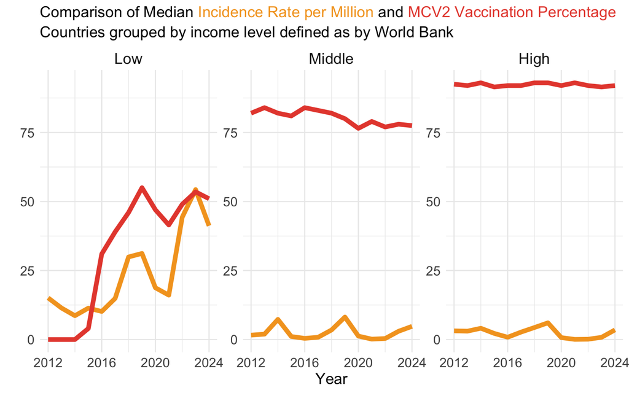

Vaccination rate are generally *higher* as the income classification group rises, which indicates generally that richer countries are more vaccinated. Low income countries have a more direct relationship between these two variables.

**GDP Per Capita Summary**

Summary Statistics for GDP Per Capita (USD) by Region in 2024

GDP classification based on mean of region: Low | Middle | High

| Region | Mean | Median | Standard Deviation | IQR | Sample Size |
| --- | --- | --- | --- | --- | --- |
| Europe | $36,001.32 | $25,972.30 | $30,868.58 | $41,982.51 | 51 |
| Western Pacific | $18,656.60 | $6,712.45 | $23,807.54 | $21,658.69 | 23 |
| Americas | $16,184.27 | $10,911.88 | $16,892.35 | $11,432.42 | 32 |
| Eastern Mediterranean | $14,803.39 | $5,081.08 | $19,589.65 | $22,343.69 | 19 |
| South East Asia | $4,771.08 | $3,303.99 | $4,852.43 | $3,114.21 | 10 |
| Africa | $2,212.71 | $1,215.45 | $2,198.39 | $1,535.17 | 42 |

**GDP and MCV2 Rate**

Side-by-side comparison of mean GDP and MCV2 Percentage

Average GDP per Capita and MCV2 Vaccine Rate by Region

| Region | Mean GDP (USD) | Mean MCV2 Coverage |
| --- | --- | --- |
| Africa | $2,307.99 | 36.3% |
| South East Asia | $4,044.05 | 79.1% |
| Americas | $13,638.39 | 74.1% |
| Eastern Mediterranean | $14,272.35 | 76.3% |
| Western Pacific | $16,535.63 | 76.5% |
| Europe | $28,913.33 | 89.1% |

**Model**

Estimated explanatory variable coefficients for a model using number of measles cases per million population as the dependent variable. Model utilizes an autocorrelation structure for the errors using year as the covariate.

Estimated coefficients for modeled variables

| Variable | Estimated coefficient | Std.Error | t-value | p-value |
| --- | --- | --- | --- | --- |
| Quantitative |  |  |  |  |
| (Intercept) | 270.541 | 68.823 | 3.931 | 0.000 |
| log(GDP per capita ($)) | −28.222 | 9.475 | −2.978 | 0.003 |
| MCV2 | −18.794 | 37.959 | −0.495 | 0.621 |
| Region (Africa as baseline) (overall p-value = 0.057) |  |  |  |  |
| Americas | 3.708 | 37.667 | 0.098 | 0.922 |
| Eastern Mediterranean | 44.753 | 38.371 | 1.166 | 0.244 |
| Europe | 79.135 | 36.790 | 2.151 | 0.032 |
| South East Asia | −12.716 | 47.101 | −0.270 | 0.787 |
| Western Pacific | 81.589 | 37.262 | 2.190 | 0.029 |

**Why Mongolia?**

We are interested in looking at Mongolia as from the table below, we see that overall, they have the highest mean number of measles cases per 1 million people, yet based on the map on the main page, they appear to have a very high vaccination rate in 2024 (95%). Knowing that vaccines tend to reduce the transmission and transfection of measles, we wanted to investigate this country further to gather more insight on possible reasons for this inconsistency in expected trend and also to see the association between number of measles and infant mortality rate.

**Key Takeaway**

Measles Cases Across the Regions of the World

Summary Statistics for Total Number of Measles Cases for Each 1 Million Individuals

| Country | Mean | Median | Standard Deviation | IQR | Sample Size |
| --- | --- | --- | --- | --- | --- |
| Western Pacific |  |  |  |  |  |
| Mongolia | 1,188.58 | 0.16 | 3,005.82 | 3.31 | 14 |
| Micronesia (Federated States of) | 268.86 | 0.00 | 1,005.97 | 0.00 | 14 |
| Tonga | 160.88 | 160.88 | 227.52 | 160.88 | 2 |
| Solomon Islands | 121.45 | 0.00 | 437.89 | 0.00 | 13 |
| Philippines | 99.68 | 23.66 | 169.05 | 28.22 | 14 |
| Europe |  |  |  |  |  |
| Kyrgyzstan | 619.84 | 80.69 | 982.27 | 879.31 | 14 |
| Georgia | 357.28 | 58.48 | 598.81 | 485.72 | 14 |
| Romania | 261.76 | 105.94 | 423.13 | 306.47 | 14 |
| Kazakhstan | 238.49 | 24.11 | 409.67 | 166.95 | 14 |
| Ukraine | 217.18 | 26.04 | 435.00 | 94.67 | 14 |
| Africa |  |  |  |  |  |
| Madagascar | 572.83 | 2.79 | 2,013.91 | 2.91 | 14 |
| Liberia | 237.17 | 90.13 | 311.58 | 304.95 | 14 |
| Equatorial Guinea | 184.97 | 24.51 | 350.79 | 112.40 | 14 |
| Gabon | 170.06 | 21.30 | 256.53 | 359.19 | 14 |
| Central African Republic | 123.73 | 37.02 | 195.00 | 60.32 | 14 |
| Eastern Mediterranean |  |  |  |  |  |
| Yemen | 307.80 | 106.69 | 373.70 | 510.64 | 14 |
| Somalia | 303.66 | 88.38 | 456.25 | 304.53 | 14 |
| Afghanistan | 82.36 | 48.56 | 101.67 | 70.18 | 14 |
| Iraq | 80.53 | 10.23 | 188.37 | 36.25 | 14 |
| Sudan | 66.09 | 58.61 | 57.99 | 65.75 | 14 |
| South East Asia |  |  |  |  |  |
| Thailand | 30.80 | 15.85 | 34.78 | 44.44 | 14 |
| Sri Lanka | 30.36 | 2.54 | 52.66 | 30.64 | 14 |
| India | 29.58 | 22.45 | 22.55 | 36.69 | 12 |
| Indonesia | 22.87 | 17.34 | 20.87 | 21.80 | 14 |
| Myanmar | 18.64 | 5.25 | 29.02 | 24.34 | 12 |
| Americas |  |  |  |  |  |
| Venezuela (Bolivarian Republic of) | 23.61 | 0.00 | 60.48 | 14.21 | 10 |
| Brazil | 16.61 | 0.63 | 31.63 | 12.74 | 12 |
| Canada | 14.38 | 1.11 | 38.97 | 4.10 | 11 |
| Belize | 3.61 | 0.00 | 11.98 | 0.00 | 11 |
| Mexico | 3.35 | 0.01 | 10.52 | 0.11 | 11 |

Percentage of Measles Cases and Mortality Over Time

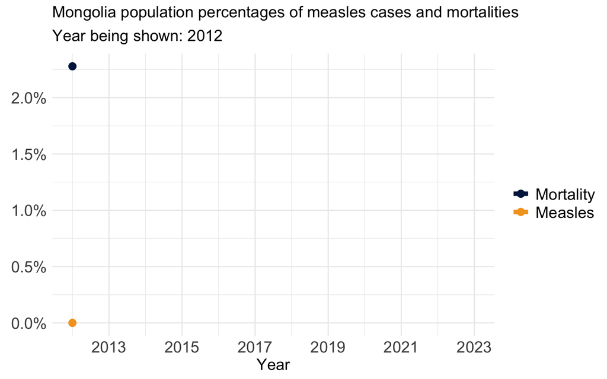